# Matrices_Ecuaciones

Universidad Autónoma del Estado de México

Centro Universitario UAEM Zumpango

Ingeniería en Computación

Graficación Computacional

Alumno: Diego Argel Navarrete Godines

Profesor: Hazem

Fecha: 23 de octubre del 2024

# Matrices y sistemas de ecuaciones

# Sistema de ecuaciones lineales

##### Un sistema de ( n ) ecuaciones con ( n ) incógnitas se puede escribir de la siguiente forma:

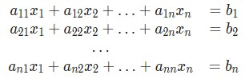

##### El sistema también se puede escribir en forma matricial de la forma:

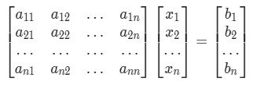

Lo que se puede reescribir de forma compacta utilizando:

$$ A x = b $$

donde ( A ) es una matriz de dimensión ( n \times n ) y ( x ) y ( b ) son dos vectores columna de longitud ( n ). En esta ecuación, se busca despejar el valor de ( x ). Para ello, asumiendo que la matriz ( A ) es regular, se puede multiplicar la expresión por la inversa de ( A ), es decir, ( A^{-1} ):

$$ A^{-1} A x = A^{-1} b $$

En este caso, ( A^{-1} A ) es la matriz identidad, por lo que se puede escribir la solución del sistema como:

$$ x = A^{-1} b $$

# Determinar si el sistema se puede resolver

```python
if np.linalg.det(A) == 0:
    x = None
    print("No se puede resolver")
else:
    x = (A**-1)*b
```

```python
print("Matriz A: ", A)
print("Matriz B: ", b)
print("Inversa: ", x)
```

```
Matriz A:  [[ 2  3]
 [ 1 -2]]
Matriz B:  [[  8]
 [-10]]
Inversa:  [[-2.]
 [ 4.]]
```

# Calcular determinantes en Python

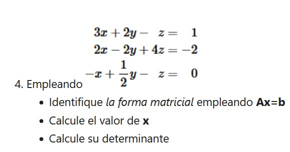

```python
A4 = np.matrix([[3, 2, -1], [2, -2, 4], [-1, 1/2, -1]])
b4 = np.matrix([[1],[-2],[0]])

print('Esto es A', A4)
print('Esto es b', b4)
```

```
Esto es A [[ 3.   2.  -1. ]
 [ 2.  -2.   4. ]
 [-1.   0.5 -1. ]]
Esto es b [[ 1]
 [-2]
 [ 0]]
```

```python
x = (A4**-1)*b4
print(x)
```

```
[[ 1.]
 [-2.]
 [-2.]]
```

```python
print(np.linalg.det(A4))
```

```
-3.0000000000000036
```

# 1. A = (9)

```python
import numpy as np

A = np.matrix([[9]])

print("this is A\n",A)
det = np.linalg.det(A)
print("this is the determinante\n",det)
```

```
this is A
 [[9]]
this is the determinante
 9.000000000000002
```

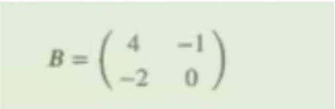

```python
B = np.array ([[4,  -1],[-2,   0]])
print(B)
```

```
[[ 4 -1]
 [-2  0]]
```

```python
print("Determinante es: ", np.linalg.det (B))
```

```
Determinante es:  -2.0
```

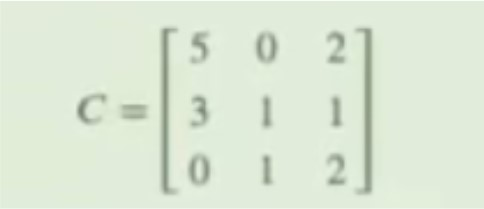

```python
C = np.array ([[5,   0,   2],[3,   1,   1],[0,   1,   2]])
print(C)
```

```
[[5 0 2]
 [3 1 1]
 [0 1 2]]
```

```python
print("Determinante es: ", np.linalg.det (C))
```

```
Determinante es:  11.000000000000002
```